# 2.08-Tree-Traversal

### Depth First Traversal (DFT) Post Order Iterative

Post-order is in a way resembling in-order in the sense that we'll again traverse down a branch, but only visit the nodes on the way back up. The difference is again in the order we make the visits.

Previously (DFT In order Iterative) we went left side(`2`) parent(`5`), then right side(`8`). With post order. We will do the left side(`2`), then the right side(`8`) and after that the parent(`5`)

So in our case here we would visit `2`, then its sibling `8`, and only after that go to their parent `5`. And now we go one level up and work on the sub tree with `9` as the parent. Since we did its left side, we must now visit its right one, so we would traverse again downwards until we can't anymore and then go again left right parent.`10` does not have a left child, so there's nothing to visit, but it has a right one. So we visit `12` and then we visit the parent. With both sides of `9` visited. We can now visit `9` itself. After that we go one level up again. We just did the left side of `15` so we moved to the right one. We again try to go as much to the left and down (`21`). We end up at the mini tree with `19` as the parent. We visit `21`, we visit `19`, then move up. Here we have the right side of `22` which is only `27`. After we visit those, we can finally visit 15. So that's how Post-order looks like

```python
def dft_post_order_iterative(self): # which means we visit: Left child → Right child → Node itself.
    if not self.root:
        raise Exception("Tree is empty")
# current is used to navigate and explore the tree.
# previous keeps track of the last visited node, which helps us decide whether we've already been to a node’s right child.
    current = previous = self.root #chained assignment: sets both current and previous to point to the root of the tree (node 29).
    stack = [] # simulates the recursive stack to remember where we came from. We use it to backtrack up the tree.
    visited = [] # will hold your final post-order traversal sequence (i.e., list of visited nodes in correct order).
    ''' This is the left descent phase. We go as far left as possible '''
    while current:
        while current.left: # While current has a left child,Update the stack with each left child,This keeps going until you reach the leftmost leaf(2).
            stack.append(current)
            current = current.left
# Remember that post-order means visiting:Left → Right → Node, So before we visit any node, we must ensure:
# a) We’ve finished its left subtree & b) We’ve finished its right subtree. In recursive post-order, this logic is handled by the function call stack.
# But here, since we’re doing it iteratively, we must keep track of this ourselves.
        ''' Backtracking and Visiting ...This is where nodes get visited and added to the result '''
# You visit a node if a.It has no right child, or b.Its right child has already been visited.
# This check ensures we're only visiting a node after completing its right subtree.
        while not current.right or current.right == previous:
            visited.append(current.data)#Now that we’ve confirmed both children are done,we visit the current node & add its data to the visited list.
            previous = current # We record this node as the most recently visited node. That way, if we return to its parent node,
                                # we’ll know whether we’ve already handled its right child.
            if not stack: # we want to check the status of the stack, if its empty it means we finished visiting all the nodes and
                return visited # return the visited array
            current = stack.pop() # Otherwise, we backtrack by popping the last node we put on the stack. We’re now ready to either:
            # a.Visit this node (if right is done), Or b. move into its right child.
        ''' Exploring right child '''
        stack.append(current)
        current = current.right
# This comes after the above while loop ends.It means: a. We’re not ready to visit the current node yet.b.Its right child exists and hasn’t been visited.
#c.so..Save current node on stack (we’ll need to come back after handling the right child) & d.Dive into the right subtree.
# If the right child hasn’t been visited, push the current node (we’ll return to it later) and move to the right.

# Output : [2, 8, 5, 12, 10, 9, 21, 19, 27, 22, 15, 31, 39, 35, 40, 45, 46, 58, 49, 44, 29]
```

1. stack@start =[] | current = 29 | previous = 29 | stack@end = [29] | current = 29.left = 15 2. while 1| stack@start =[29,15] | previous = 29 | current = 15.left = 9 3. while 1| stack@start =[29,15,9] | previous = 29 | current = 9.left = 5 4. while 1| stack@start =[29,15,9,5] | previous = 29 | current = 5.left = 2 5. while 1 is true but while 2 = 2.left is false | Jump to while 3 - check if 2.right is none or current(2) == prev(29) | visited = [2] | previous = 2 check if stack is empty = false | current = pop(5) | stack@end =[29,15,9] 6. while 3 is false | stack = [29,15,9,5] | current = 5.right = 8 | Now main Loop starts over 7. while 1 is True | while 2 is false | while 3 is True | visited = [2,8] | previous = 8 | current = pop(5) | stack@end =[29,15,9] 8. while 3 is True | visited = [2,8,5] | previous = 5 | current = pop(9) | stack@end =[29,15] 9. while 3 is false | stack = [29,15,9] | current = 9.right = 10 | Now main Loop starts over 10.while 1 is True | while 2 is false | while 3 is false | stack = [29,15,9,10] | current = 10.right = 12 | Now main Loop starts over 11.while 1 is True | while 2 is false | while 3 is True | visited = [2,8,5,12] | previous = 12 | current = pop(10) | stack@end =[29,15,9] 12.while 3 is True = 10.right(12) == prev(12) | visited = [2,8,5,12,10] | previous = 10 | current = pop(9) | stack@end =[29,15] 13.while 3 is True = 9.right(10) == prev(10) | visited = [2,8,5,12,10,9] | previous = 9 | current = pop(15) | stack@end =[29] 14.while 3 is false | stack = [29,15] | current = 15.right = 22 15.while 1 is True | while 2 is True | stack = [29,15,22] | current = 22.left = 19 16.while 2 is false | while 3 is false | stack = [29,15,22,19] | current = 19.right = 21 17.while 1 is True | while 2 is false | while 3 is True | visited = [2,8,5,12,10,9,21] | previous = 21 | current = pop(19) | stack@end =[29,15,22] 18.while 3 is True | visited = [2,8,5,12,10,9,21,19] | previous = 19 | current = pop(22) | stack@end =[29,15] 20.while 3 is false | stack =[29,15,22] | current = 22.right = 27 21.while 1 is True | while 2 is false | while 3 is True | visited = [2,8,5,12,10,9,21,19,27] | previous = 27 | current = pop(22) | stack =[29,15] 22.while 3 is True | visited = [2,8,5,12,10,9,21,19,27,22] | previous = 22 | current = pop(15) | stack =[29] 23.while 3 is True | visited = [2,8,5,12,10,9,21,19,27,22,15] | previous = 15 | current = pop(29) | stack =[] 24.while 3 is false | stack = [29] | current = 29.right = 44 25.while 1 is True | while 2 is True | stack = [29,44] | current = 44.left = 40 ------------------------------------------------ Rest completed using ChatGPT ------------------------------------------------------------- 26. while 1 is True | while 2 is True | stack = [29,44,40] | current = 40.left = 35 27. while 1 is True | while 2 is True | stack = [29,44,40,35] | current = 35.left = 31 28. while 1 is True | while 2 is false | while 3 is True | visited = [2,8,5,12,10,9,21,19,27,22,15,31] |previous=31|current=pop(35)|stack@end=[29,44,40] 29. while 3 is false | stack = [29,44,40,35] | current = 35.right = 39 30. while 1 is True | while 2 is false | while 3 is True|visited = [2,8,5,12,10,9,21,19,27,22,15,31,39] |previous=39|current=pop(35)|stack@end=[29,44,40] 31. while 3 is True | visited = [2,8,5,12,10,9,21,19,27,22,15,31,39,35] | previous = 35 | current = pop(40) | stack@end = [29,44] 32. while 3 is True | visited = [2,8,5,12,10,9,21,19,27,22,15,31,39,35,40] | previous = 40 | current = pop(44) | stack@end = [29] 33. while 3 is false | stack = [29,44] | current = 44.right = 49 34. while 1 is True | while 2 is True | stack = [29,44,49] | current = 49.left = 46 35. while 1 is True | while 2 is false | stack = [29,44,49,46] | current = 46.right = 45 36. while 1 True|while 2 false|while 3 is True|visited=[2,8,5,12,10,9,21,19,27,22,15,31,39,35,40,45]|previous=45|current=pop(46)|stack@end= [29,44,49] 37. while 3 is True | visited = [2,8,5,12,10,9,21,19,27,22,15,31,39,35,40,45,46] | previous = 46 | current = pop(49) | stack@end = [29,44] 38. while 3 is false | stack = [29,44,49] | current = 49.right = 58 39. while 1 True|while 2 false|while 3 is True|visited=[2,8,5,12,10,9,21,19,27,22,15,31,39,35,40,45,46,58]|previous=58|current=pop(49)|stack@end=[29,44] 40. while 3 is True | visited = [2,8,5,12,10,9,21,19,27,22,15,31,39,35,40,45,46,58,49] | previous = 49 | current = pop(44) | stack@end = [29] 41. while 3 is True | visited = [2,8,5,12,10,9,21,19,27,22,15,31,39,35,40,45,46,58,49,44] | previous = 44 | current = pop(29) | stack@end = [] 42. while 3 is True | visited = [2,8,5,12,10,9,21,19,27,22,15,31,39,35,40,45,46,58,49,44,29] | previous = 29 | stack empty → traversal complete

When coders design an algorithm like **iterative post-order traversal**, what they’re really doing is reverse-engineering the behavior of a recursive call stack—which is invisible but incredibly powerful. They ask themselves: “If recursion works by holding a place on the system call stack until left and right are processed, how do I replicate that logic explicitly using my own stack?”

To make that happen, they needed a clever strategy to:

- Track where they came from → using a stack.
- Know what’s already been visited → using previous.
- Avoid revisiting right children → with that subtle condition you now understand.

It’s like building a map with signs that say “I’ve already explored this path, don’t go there again.” That level of precision takes both logical thinking and creative insight.

Coders often sketch it out by hand, simulate tiny trees, debug dozens of edge cases, and refine until it behaves like nature intended. That mental model—the one you just built from tracing node 2 to 29—is the same one they used to create it.

### Depth First Traversal (DFT) Post Order Recursive

In the preorder version, we visit the node prior to traversing to the left and right . The in order does the visiting in between traversing the left and right children (below). So naturally Post order will do the visiting after the traversing part.

```python
def _traverse(node): # Pre Order = Root → Left → Right. Use case: Often used to copy or serialize a tree,because you record the root before its children.
    """ DFT Pre Order Recursive """
    if node:
        visited.append(node.data) # code # 1
        _traverse(node.left)      # code # 2
        _traverse(node.right)     # code # 3
    return
""" Output : [29, 15, 9, 5, 2, 8, 10, 12, 22, 19, 21, 27, 44, 40, 35, 31, 39, 49, 46, 45, 58] """

def _traverse(node): # In Order = Left → Root → Right. Use case: For Binary Search Trees (BSTs), this traversal gives you the nodes in sorted order
    """ DFT In Order Recursive """
    if node:
        _traverse(node.left)        # code # 2 swapped with code # 1
        visited.append(node.data)   # code # 1 swapped with code # 2
        _traverse(node.right)       # code # 3 remains as it is
    return
""" Output : [2, 5, 8, 9, 10, 12, 15, 19, 21, 22, 27, 29, 31, 35, 39, 40, 44, 45, 46, 49, 58]"""


def _traverse(node): # Post Order = Left → Right → Root.
    """ DFT Post Order Recursive """
    if node:
        _traverse(node.left)
        _traverse(node.right)
        visited.append(node.data)
    return
""" Output : [2, 8, 5, 12, 10, 9, 21, 19, 27, 22, 15, 31, 39, 35, 40, 45, 46, 58, 49, 44, 29]"""
```

```
' Output : [2, 8, 5, 12, 10, 9, 21, 19, 27, 22, 15, 31, 39, 35, 40, 45, 46, 58, 49, 44, 29]'
```

```python
def dft_post_order_recursive(self):
    if not self.root:
        raise Exception("Tree is Empty")
    visited = []

    def _traverse(node):
        if node:
            _traverse(node.left)
            _traverse(node.right)
            visited.append(node.data)
        return

    _traverse(self.root)
    return visited
```

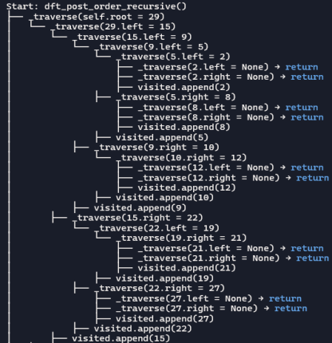

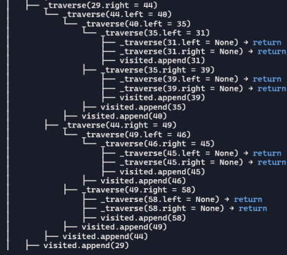

### Summary

So we just learned two main approaches of traversing a tree 1.breadth first and 2.depth first. And they ultimately do the same thing. They visit all the nodes in a tree. So assuming we don't have any other reason to do one over the other, let's think which one would be better in certain scenarios in terms of performance. It's true that they all have an O(n) complexity, but there are some cases where one would be a better choice

This is a perfectly balanced tree, one which grows exponentially the deeper it goes. In a breadth first traversal, we would go level by level and use a queue to store the nodes we'll visit next. And we saw that the queue will contain, at some point all the nodes that are found at every level.

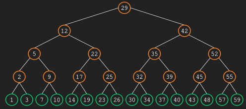

So at the top it will contain only the root. Then the two nodes at the second level, then these four and so on. And when it reaches the bottom level, the queue will have all the leaf nodes in memory at the same time. In this type of tree, that number would be about half the total number of nodes. For large trees, or if we're short on available memory, that could be an issue.

With depth first though, where storing the nodes that go from the top of a branch to the bottom. And in this type of tree, you can see that the number is considerably smaller than what we had before. So a depth first approach would be a better choice in this case

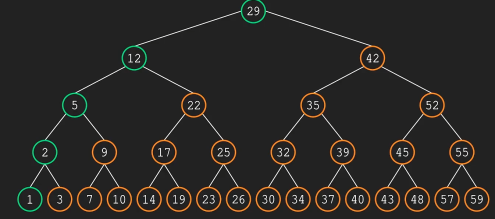

But what about this tree below ? Here we have one which is deeper, but much narrower at its widest. We only have three nodes, so a breadth first traversal will only keep at most three nodes in memory at any point. If we were to traverse it depth first, the depth of the branch will dictate the number of nodes we have to add to the stack. And you can see here that there's a big difference between the two methods.

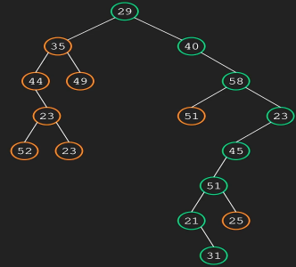

The point is, if visiting every node is the sole purpose, regardless in which order, and you need to be conscious about memory utilization, choosing the best method depending on the structure of your tree would be a good idea.

Let's also have another look at the three depth first variations and when we would want to use one over the others. This would be the order we would get if we were to traverse the tree. Preorder .This method is typically used when we want to linearize a tree, that is, to represent it as a list.

This will help us if we want to make a copy of the tree, because if we were to iterate over the list of visited nodes and insert them in a new binary search tree, the nodes will be inserted in the same order as before.

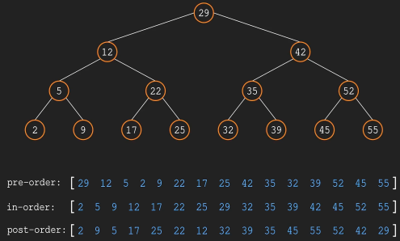

So the preorder method preserves the structure of the tree if we want to use it at a later moment. In order would give us this result if the tree were traversing is a binary search tree. The list we get back would actually be the ascending order of our elements. Traversing from the right side will of course, give us the descending order. This might be useful to find out the structure of the tree.

For example, to see how many elements you have that are less than or greater than the root. As we already learned, post order would visit the leaves first before moving up to the parent node. This in and of itself can be a reason to choose this type of method, but another practical use of post order is to delete a tree from the leaves up. So it's all situational, as is everything with programming. We choose our solutions based on the problem we're trying to solve

### Tree Traversal Use Cases (BFT vs DFT)

##### 📌 Breadth‑First Traversal (BFT)

**Definition:** Explore nodes level‑by‑level (horizontal expansion).

##### Real‑Life Use Cases

- **Shortest Path in Unweighted Graphs**  
  GPS navigation, routing protocols, or network packet delivery.
- **Social Network Analysis**  
  Finding friends‑of‑friends or community detection.
- **Web Crawling**  
  Search engines crawl pages breadth‑wise to discover all links at a given depth before moving deeper.
- **Garbage Collection (Memory Management)**  
  Mark‑and‑sweep algorithms traverse object references breadth‑wise.
- **Disaster Spread Simulation**  
  Modeling wildfire spread or disease transmission, where expansion happens in waves.

##### 📌 Depth‑First Traversal (DFT)

**Definition:** Explore nodes branch‑by‑branch (vertical expansion).  
Types: Pre‑Order, In‑Order, Post‑Order.

##### Real‑Life Use Cases

- **Expression Tree Evaluation (Post‑Order)**  
  Compilers evaluate arithmetic expressions bottom‑up.
- **Route Finding in Maps (DFS)**  
  Explore all possible paths deeply before backtracking.
- **Topological Sorting / Dependency Resolution**  
  Build systems (`make`) or task schedulers ensure dependencies are resolved before parent tasks.
- **File System Traversal**  
  DFS is used to list or delete directories (children before parent).
- **Game AI (Minimax)**  
  DFS explores all possible moves down to terminal states before evaluating.

##### 📊 Comparison Table

| Traversal | Exploration Style | Typical Use Cases | Key Advantage |
| --- | --- | --- | --- |
| **BFT** | Level‑by‑level (queue) | Shortest path, social networks, web crawling, garbage collection, spread simulation | Guarantees shortest path in unweighted graphs |
| **DFT** | Branch‑by‑branch (stack/recursion) | Expression evaluation, route finding, dependency resolution, file systems, game AI | Memory efficient, explores all paths |

##### ✅ Key Insight

- Use **BFT** when you need **shortest paths or level‑wise exploration**.
- Use **DFT** when you need **complete exploration, dependency resolution, or bottom‑up evaluation**.